# R Notebook

```r
library(CodeClanData)
library(tidyverse)
```

```r
backpack <- backpack
```

2. What is the distribution of backpack weights that students are carrying? Choose an appropriate graph to show the distribution.

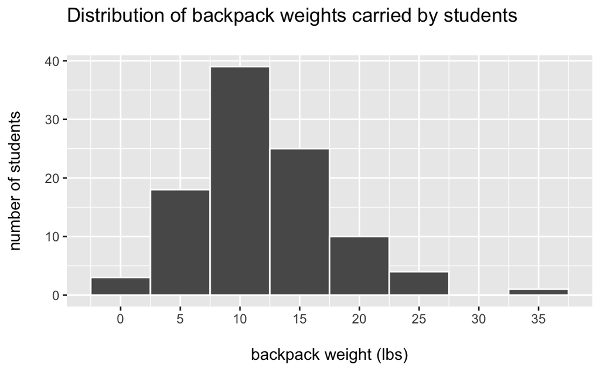

```r
ggplot(backpack)+
  aes(x = backpack_weight)+
  geom_histogram(colour = "white", binwidth = 5)+
  scale_x_continuous(breaks = c(0,5,10,15,20,25,30,35))+
  labs(title = "Distribution of backpack weights carried by students\n",
       x = "\nbackpack weight (lbs)",
       y = "number of students\n")
```

Description: The most common weight of student backpack is 10 pounds. The majority of students carry backpack that weight between 5 to 15 pounds.

3. Are there differences in backpack weight between sex?

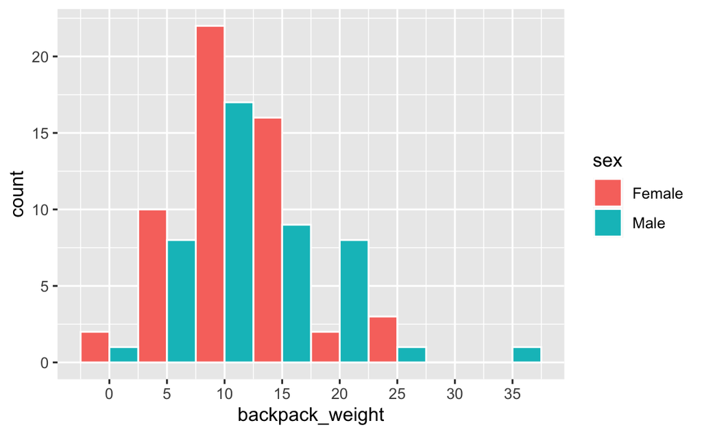

```r
ggplot(backpack)+
  aes(x = backpack_weight, fill = sex)+
  geom_histogram(colour = "white", position = "dodge", binwidth = 5)+
  scale_x_continuous(breaks = c(0,5,10,15,20,25,30,35))
```

```r
  labs(title = "Distribution of backpack weights carried by students",
       subtitle = "Differences between gender\n",
       x = "\nbackpack weight (lbs)",
       y = "number of students\n",
       fill = "gender")
```

```
$x
[1] "\nbackpack weight (lbs)"

$y
[1] "number of students\n"

$fill
[1] "gender"

$title
[1] "Distribution of backpack weights carried by students"

$subtitle
[1] "Differences between gender\n"

attr(,"class")
[1] "labels"
```

Description: There is overall higher number of Female students carrying backpacks than Male students.

4. What is the relationship between body weight and backpack weight?

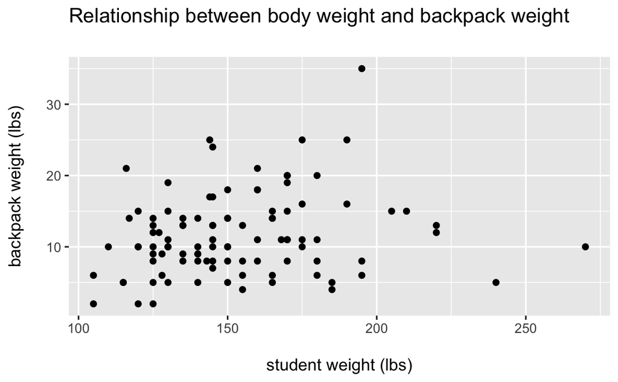

```r
ggplot(backpack)+
  aes(x = body_weight, y = backpack_weight)+
  geom_point()+
  #geom_smooth(method = "lm", se = FALSE)+
  labs(title = "Relationship between body weight and backpack weight\n",
       x = "\nstudent weight (lbs)",
       y = "backpack weight (lbs)\n")
```

Description: There is no relationship between body weight and student backpack weight. Most of the students carry backpacks of weight 5 to 20 pounds with no relation to the body weight.

5. Is this relationship different between men and women? Choose an appropriate plot and interpret your findings.

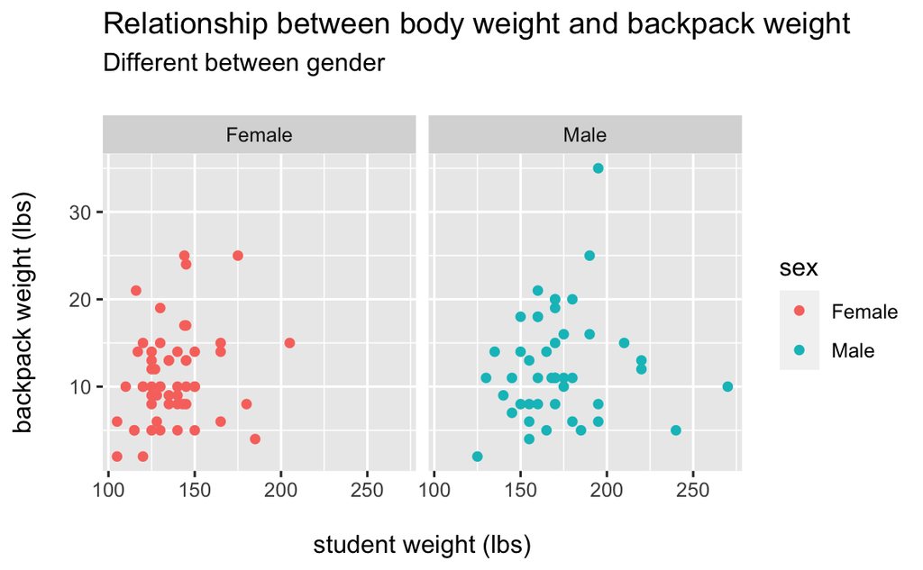

```r
ggplot(backpack)+
  aes(x = body_weight, y = backpack_weight, colour = sex)+
  geom_point()+
  #geom_smooth(method = "lm", se = FALSE)+
  facet_wrap(~ sex)+
  labs(title = "Relationship between body weight and backpack weight",
       subtitle = "Different between gender\n",
       x = "\nstudent weight (lbs)",
       y = "backpack weight (lbs)\n")
```

Female backpack weight is mainly centered around 5 to 15 pounds and weight is centered around 100 to 170 pounds. While Male backpack weight is mostly in between 5 to 20 pounds and weight around 125 to 200 pounds. Plot suggests that women might weigh less, but they’re not carrying less heavy backpacks

6. What proportion of students report back pain?

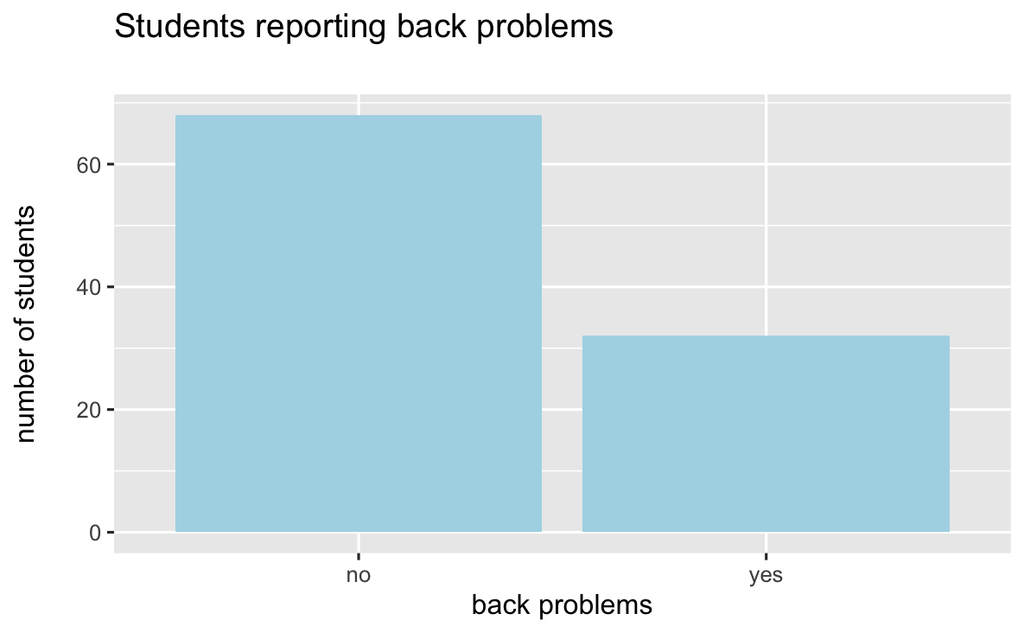

```r
backpack_bp <- backpack %>%
  mutate(back_problems = if_else(back_problems == 1, "yes", "no"))

ggplot(backpack_bp)+
  aes(x = back_problems)+
  geom_bar(fill = "light blue")+
  labs(title = "Students reporting back problems\n",
       x = "back problems",
       y = "number of students\n")
```

Description: Approximately 1/3 of the students report back problems.

7. Is this proportion different between men and women?

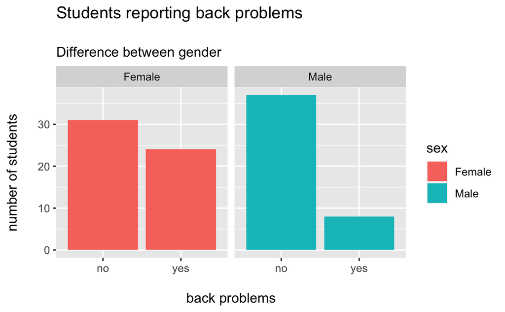

```r
ggplot(backpack_bp)+
  aes(x = back_problems, fill = sex)+
  geom_bar()+
  facet_wrap(~sex)+
  labs(title = "Students reporting back problems\n",
       subtitle = "Difference between gender",
       x = "\nback problems",
       y = "number of students\n")
```

Description: Majority of students reporting back pain are females.

Exceptions:

1. Does reported backpain differ across the year groups? Ignore year 0 in your data.

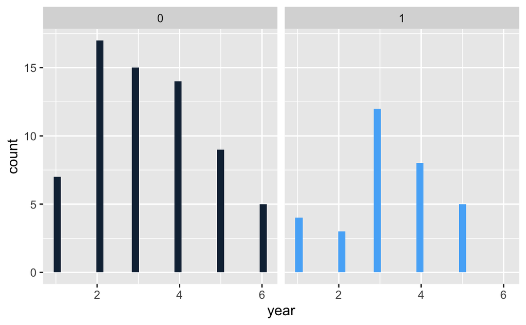

```r
backpack %>%
  filter(year > 0) %>%
  ggplot()+
  aes(x = year, group = back_problems, fill = back_problems) %>%
  geom_histogram()+
  facet_wrap(~back_problems)+
  theme(legend.position = "none")
```

```r
NA
```

2. Is there a difference between how heavy the bags are in different years?

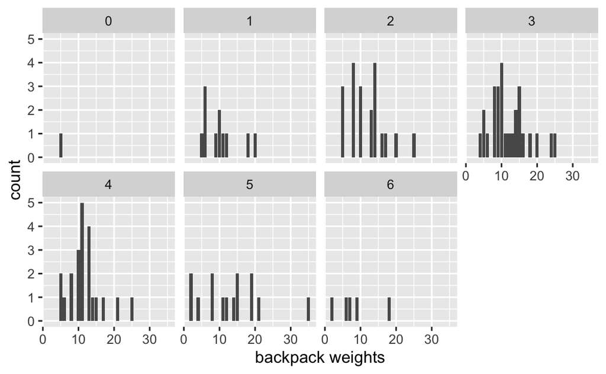

```r
ggplot(backpack)+
  geom_bar(aes(x = backpack_weight)) +
  facet_wrap(~ year, ncol = 4) +
  xlab("backpack weights")
```